# Spatial Autocorrelation Module

Lara, Brenna, Greg

December 2, 2019

# Spatial Autocorrelation with a group of *MORANS*

## Objectives

> Comparing spatial autocorrelaton statistics

## Topics

[figure not shown]

When talking about anything spatial we need to consider that variables are in fact NOT independent of each other. Not only do different variables have an effect on each other, a single variable may affect different points in space. Closer points are more related to each other than points further away and therefore closer points have greater influence on each other. Spatial autocorrelation is therefore “the correlation between the values of a single variable that is strictly due to the proximity of these values in geographical space by introducing a deviation from the assumption of independent observations of classical statistics (Griffith, 2003).”

In order to access this correlation we need to understand how the features or objects with the variable are related to each other. In other words, we need a way to describe using statistics the spatial distribution of objects with one or more attributes.

There are a few statistics used to assess patterns and spatial relations of objects. We will cover the most common types of statistics used for spatial autocorrelation in this module.

Join Count Statistics

- Global Moran’s I
- Geary’s C
- Local Moran’s I

## Example of Patterns

In general there are three patterns that the above statistics can distinguish between

- clustered, clumped, or patchy
- Uniform or even distribution
- Random distribution (no discernable pattern)

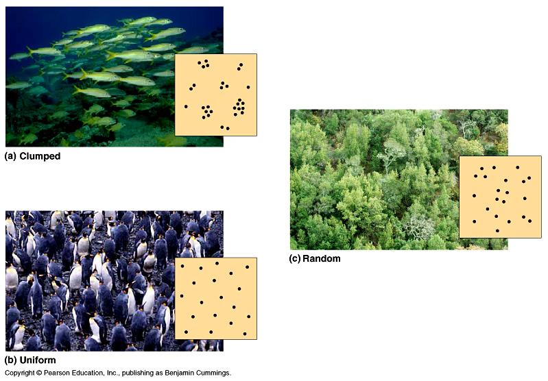

Example of Patterns

Much of spatial analysis deals with understanding how objects or attributes are clustered together. In general, we consider random distributions, uniform distributions, and clustered distributions to be the focus of our analysis.

The statistics used to analyze these clusters are therefore, trying to tell us how closely related objects are in space.

When dealing with spatial data we must also considered that objects next to each other may have influence on one another. That is, objects in space are not, in fact indepdent, but are rather dependent and the intensity of dependencies varies by how close two objects or neighborhoods are to each other. The statistics must reflect this dependency and are the proccess of relating clustered values together is known as spatial autocorrelation.

# Getting Data

We need a few packages

```r
suppressPackageStartupMessages({
library(curl)
library(ape) #you may need to install this package first
library(spdep) #for spatial autocorrelation
library(ncf)
library(raster)
library(pgirmess) #to create your raster grid cells
library(gstat)
library(dismo)
library(igraph)
library(dplyr)
library(ggplot2)})
```

Let us pull in our example data sets

[figure not shown]

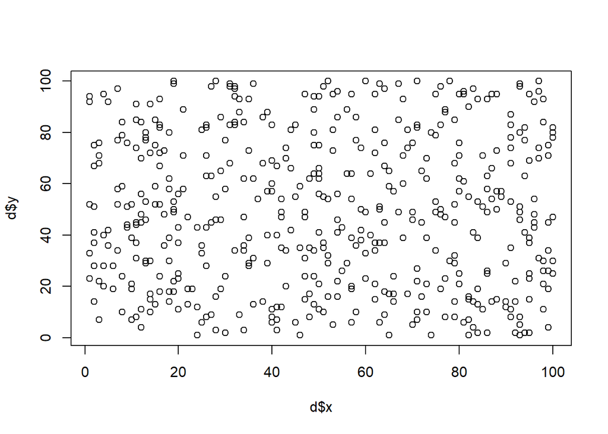

```r
#Random Data
f <- curl("https://raw.githubusercontent.com/brennastallings/SpatialAnalysisModule/master/Made%20Data/Example_Data_Random")
d <- read.csv(f, header = TRUE, sep = ",", stringsAsFactors = FALSE)
plot(d$x, d$y)
```

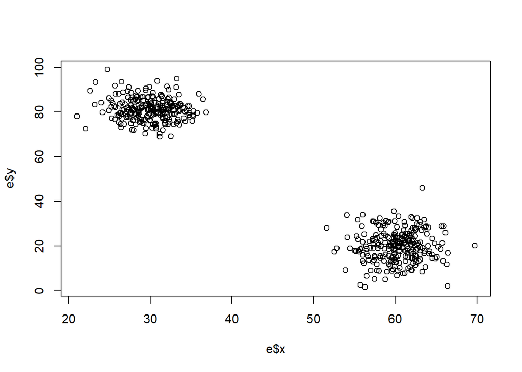

```r
#Clumped Data
c <- curl("https://raw.githubusercontent.com/brennastallings/SpatialAnalysisModule/master/Made%20Data/Example_Data_Clumped")
e <- read.csv(c, header = TRUE, sep = ",", stringsAsFactors = FALSE)
plot(e$x, e$y)
```

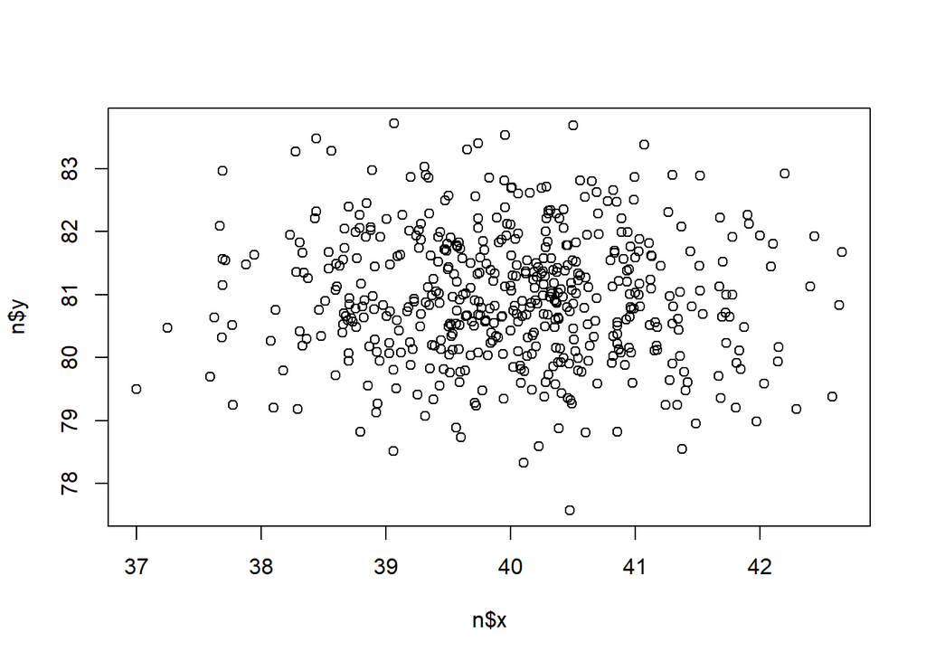

```r
#Very Clumped Data
m <- curl("https://raw.githubusercontent.com/brennastallings/SpatialAnalysisModule/master/Made%20Data/Example_Data_ExtraClumped")
n <- read.csv(m, header = TRUE, sep = ",", stringsAsFactors = FALSE)
plot(n$x, n$y)
```

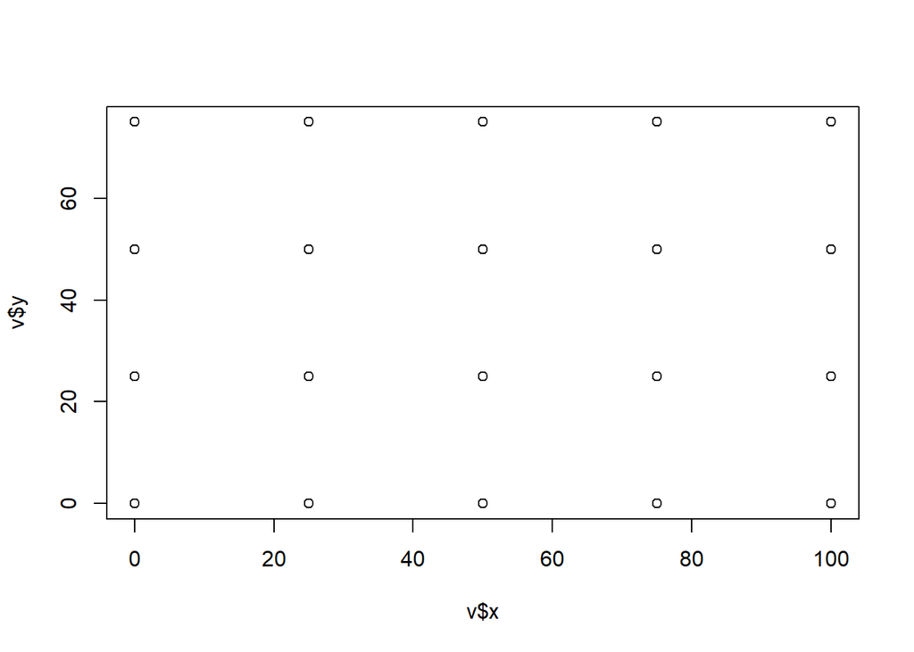

```r
#Uniform Data
u <- curl("https://raw.githubusercontent.com/brennastallings/SpatialAnalysisModule/master/Made%20Data/Example_Data_Uniform")
v <- read.csv(u, header = TRUE, sep = ",", stringsAsFactors = FALSE)
plot(v$x, v$y)
```

```r
uf<- curl("https://raw.githubusercontent.com/brennastallings/SpatialAnalysisModule/master/Made%20Data/Example_Data_Uniform500")
u.50<- read.csv(uf, header = TRUE, sep = ",", stringsAsFactors = FALSE)

#real data from Harvard forest on tree distributions.
HTrees <- read.csv("http://harvardforest.fas.harvard.edu/data/p03/hf032/hf032-01-tree.csv")
```

# Lets talk about Rasterization

## Vectors vs Rasters

There are 2 main types of data that can be used with spatial data, called vectors and rasters. Vector data is when the data is used as points, lines, and polygons, such as our orginal data, which is stored as points. We then convert the data to raster format for our statistics. The main pros of using polygon data is that it is more spatially accurate. The polygons can be created to fit the data, and uses smaller fie/storage size. However, vector data doesnt work well with continuous data.

The point to polygon transformation can be particularly useful. Polygons help visualize nearest neighbors. One type of polygon is the priximity polygon, or Voronoi polygon, which has each polygon surrounding the area of an object or point.

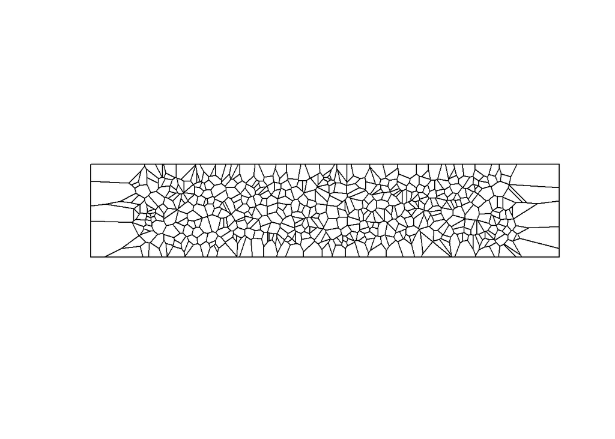

```r
#Random Data
poly2<- voronoi(d)
plot(poly2)
```

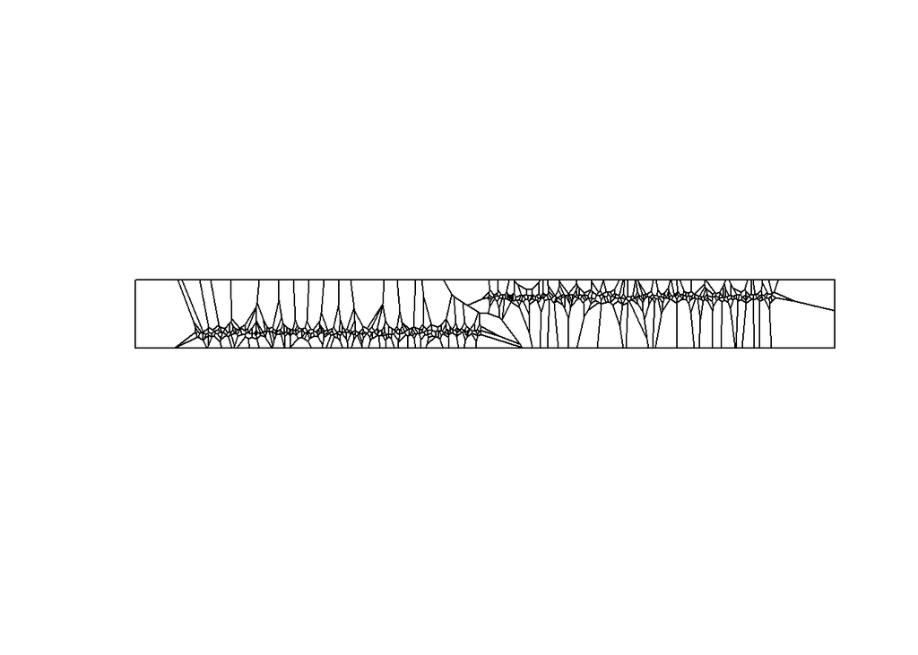

```r
#Clumped Data
poly<-voronoi(e)
plot(poly)
```

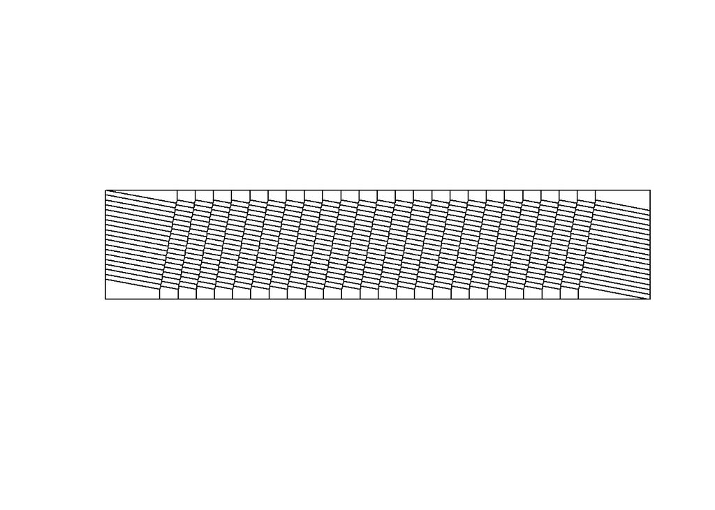

```r
#Uniform Data
poly3<- voronoi(u.50)
plot(poly3)
```

Raster data uses a matrix of cells to represent the data, using either categorical or continuous variables. It works better than polygons for continuous data such as elevation and temperature. Raster data can be used in a few ways. The data can be assumed to exist at the center of the cell or across the whole cell. You can define a cell’s contents based on either the center point, majority, or average value. Raster data is useful for very large datasets and images, espeically in remote sensing data.

Raster data also has a standard cell size across the area which is defined by the user. The size of the cells determines the spatial resolution, and therefore the spatial scale to which patterns are accurate. You need to pay attention to and carefully consider cell size for rasters. Picking the wrong size of cells can lead to pixelation of data and loss of information, while using a very small cell size can make the file size unweildy.

## Brennas Pet Potato

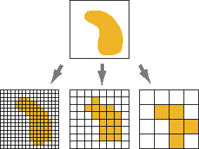

Example for Raster size importance

We will be using raster data for a couple of reasons. The main ones being that some of the packages that we use in this modlue require raster data to work, so we have no choice, and that it makes you learn how to convert between the data types.

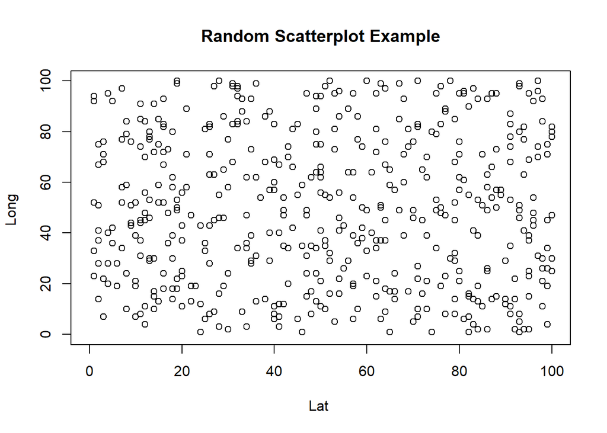

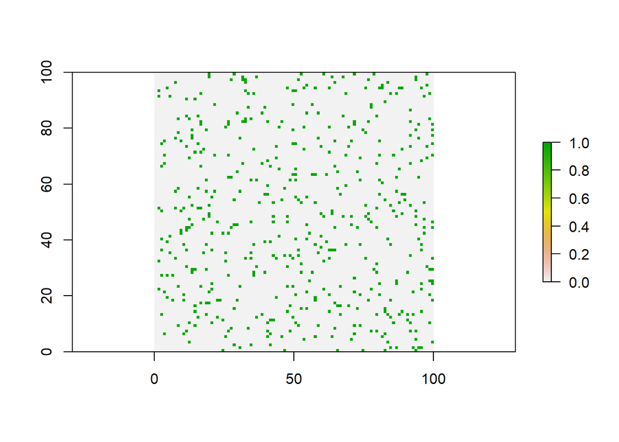

```r
#First we get the needed columns from the data into a new format for the package
random.spdf <- cbind(d$x,d$y)
#Next we define the extent, or size, of the plot the data is found in
jc.extent <- extent(0,100,0,100)
# Then we set up a blank raster, which we will then put the data into
r <- raster(nrows=100, ncols=100, ext=jc.extent,)
r1<- raster(nrows=25, ncols=20, ext=jc.extent)
#Then we assign the data to the raster
random.rast1<-rasterize(random.spdf, r, field = 1)
random.rast1[is.na(random.rast1)] <- 0
plot(random.rast1)
```

As in the picture we showed earlier, changing the size of cells in the raster changes the pixelation of the output, this one with a cell size of 3.3 x 3.3 pixels instead of 1 x 1 pixels in the first. Visually compare the two different rasters.

[figure not shown]

```r
#First we get the needed columns from the data into a new format for the package
random.spdf <- cbind(d$x,d$y)
#Next we define the extent, or size, of the plot the data is found in
jc.extent <- extent(0,100,0,100)
# Then we set up a blank raster, which we will then put the data into
r <- raster(nrows=30, ncols=30, ext=jc.extent)
#Then we assign the data to the raster
random.rast<-rasterize(random.spdf, r, field = 1)
random.rast[is.na(random.rast)] <- 0
plot(random.rast)
```

Once data is rasterized, you can identify cells that are connected, using the clump function, and can identify the edges, or transitions, between cell values.

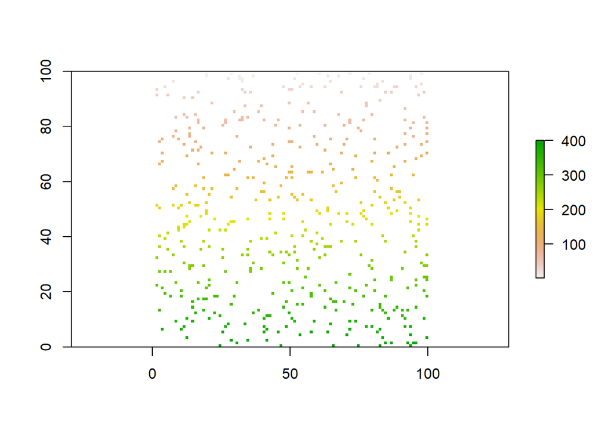

```r
rand.clump<-clump(random.rast1)
plot(rand.clump)
```

[figure not shown]

```r
clump.clump<- clump(clumped.rast)
plot(clump.clump)
```

The boundaries are cells that have more than 1 class in the cells around them

[figure not shown]

```r
plot(boundaries(clumped.rast, classes=T))
```

# Local v Global

One thing to keep in mind with all the stats that we will be using is the difference between local and global stats and what they are calculating. Many of the functions we will be using can calculate either one, but you need to know which one you want. Global tests look for clustering within your entire dataset, while local stats can distinguish clustering in smaller subsections, working at a smaller scale.

# Spatial Weight

## What are Weight Counts? And is impolite to ask?

First we will look at our clumped data

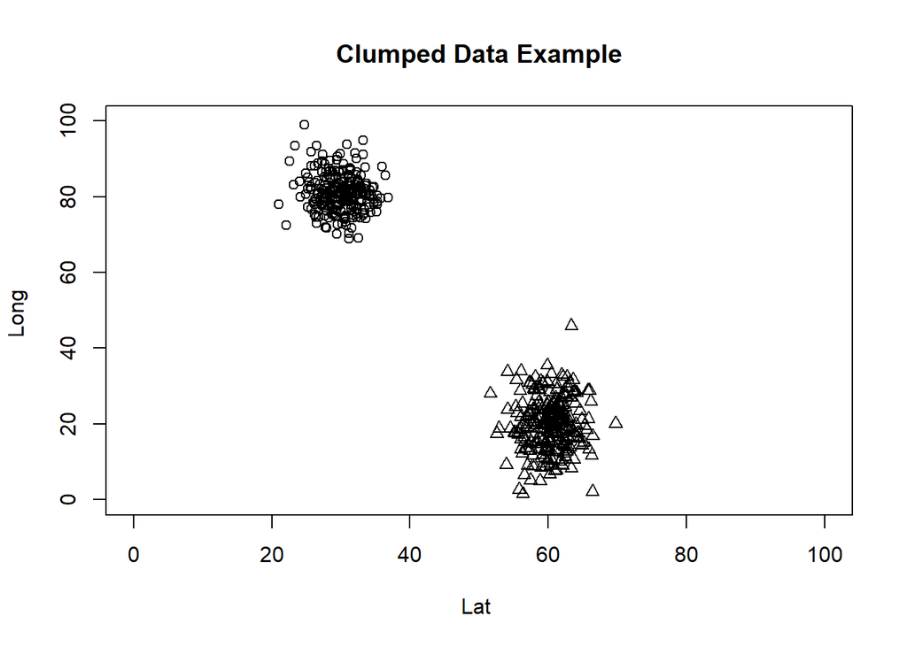

Next, we want to make a distance matrix and inverse distance matrix

```r
e.small<- sample_n(e[2:3], size=5, replace=F)
e.dis<- pointDistance(e.small, lonlat=F)
#make the  matrix
w<- 1/e.dis
w
```

```
##            [,1]       [,2]       [,3]       [,4]       [,5]
## [1,]        Inf 0.27811616 0.16171333 0.01362603 0.35761480
## [2,] 0.27811616        Inf 0.10810064 0.01304981 0.15748218
## [3,] 0.16171333 0.10810064        Inf 0.01484146 0.19986603
## [4,] 0.01362603 0.01304981 0.01484146        Inf 0.01403423
## [5,] 0.35761480 0.15748218 0.19986603 0.01403423        Inf
```

Inverse distance matricies and distance weighting assume that points that are closer togther are more statistically significant.

Different ways we can compare neighbors or define neighborhoods -Define what a neighborhood is -Inverse distance weighting as the most common -Rook, queen, bishop moves for raster data

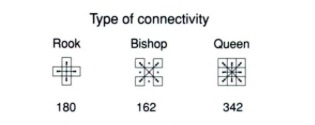

Examples of Neighbors

- Distance bands - discrete neighborhoods define by distance from a cell or polygon that is pre-assigned by the user. Anything that falls withing that radius is part of the neighborhood.

# Come on Morans, You cant stop us!… Lets play with stats now!

Let us start with join count analysis. This type of analysis looks at sets of data that have character attributes and spatial location. Character attributes can include prescence/abscence data as well as characterizations such as blue versus red states. Join count statistics can tell you whether your data is clumped, randomly dispersed, or uniformly dispersed. Join count statistics are typically used when dealing with polygons rather than points.

To start we will use tree data from Harvard and then apply this methodology to our own data that we created.

First we need to create a raster for our data. Be careful when you define your raster size as the size may be dependent on the type of data you have and the data limitations.

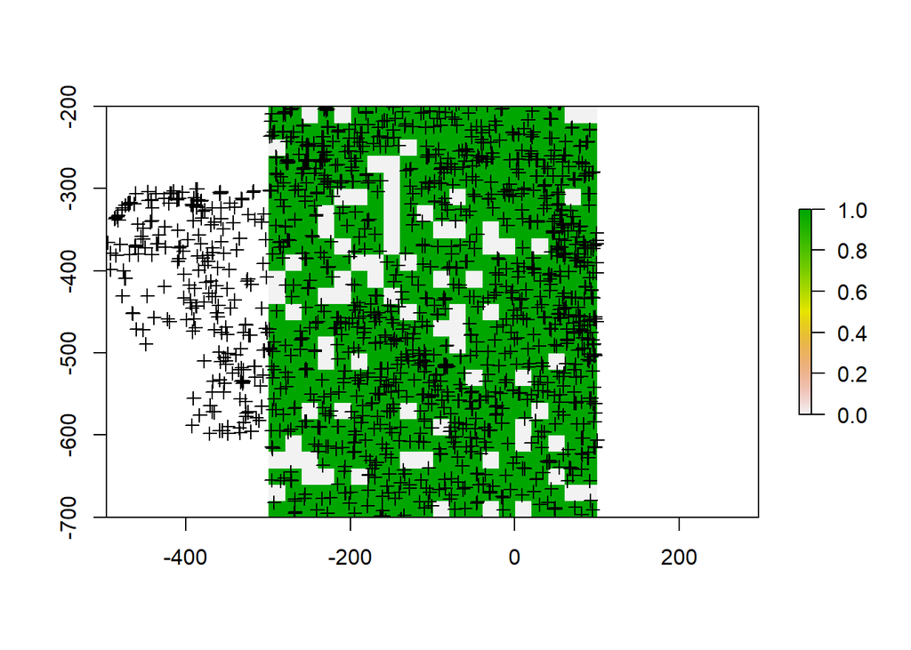

```r
# Create subset of data for Acer rubrum
acru <- subset(HTrees, species == "ACRU" & dbh91 != "NA", select = c("xsite", "ysite", "dbh91"))

# Convert tree data to SpatialPointsDataFrame, both for entire dataset, and # for individual species
acru.spdf <- acru
coordinates(acru.spdf) <- c("xsite", "ysite")

#Define the extent for the join count analyses
jc.extent <- extent(-300,100,-700,-200)
#set up a blank raster
r <- raster(nrows=25, ncols=20, ext=jc.extent)

acru.rast<-rasterize(acru.spdf, r, field = 1)
acru.rast[is.na(acru.rast)] <- 0
# You can plot the result
plot(acru.rast)
# You can plot the points on top of the raster to verify it is correct
# Remember - we only mae the raster for a subset of the data, so there will be points in a larger area than the raster covers
plot(acru.spdf, add = TRUE)
```

```r
# Generate neighbors list - the function is 'cell2nb' and the arguments are
# the number of rows and colums in your grid; you can simply get those
# characteristics from your any of your rasters using 'nrow' and 'ncol'
# commands, nested in the cell2nb function (as ilustrated below). Note, the
# default for this is 'rook', but you can change the join counts to 'queen'
# by adding the argument 'type='queen'.
nb.acru <- cell2nb(nrow = nrow(acru.rast), ncol = ncol(acru.rast))
# To calculate neighbors for queen configuration
nb.queen <- cell2nb(nrow = nrow(acru.rast), ncol = ncol(acru.rast), type = "queen")
# Convert the neighbors list to a 'weights' list; again, this will be the
# same for all species we are analyzing. You an follow the example below
# using 'style='B' (as a Binary weights matrix). Again, calculate this for
# the queen setup as well as the default (rook) setup.
lwb.acru <- nb2listw(nb.acru, style = "B")
lwb.queen.acru <- nb2listw(nb.queen, style = "B")

# First, the regular join count test for Acer rubrum (Testing the hypothesis
# of aggregation among like categories; add the argument 'alternative='less'
# to reverse this)
joincount.test(as.factor(acru.rast@data@values), lwb.acru, alternative = "greater") # Second, the permutation-based jon count test; similar to above, and you
```

```
##
##  Join count test under nonfree sampling
##
## data:  as.factor(acru.rast@data@values)
## weights: lwb.acru
##
## Std. deviate for 0 = 1.474, p-value = 0.07024
## alternative hypothesis: greater
## sample estimates:
## Same colour statistic           Expectation              Variance
##              29.00000              22.98890              16.63047
##
##
##  Join count test under nonfree sampling
##
## data:  as.factor(acru.rast@data@values)
## weights: lwb.acru
##
## Std. deviate for 1 = 1.2167, p-value = 0.1119
## alternative hypothesis: greater
## sample estimates:
## Same colour statistic           Expectation              Variance
##             686.00000             680.02890              24.08497
```

```r
# can adjust the number of simulations with the 'nsim' argument
joincount.mc(as.factor(acru.rast@data@values), lwb.acru, nsim = 999, alternative = "greater")
```

```
##
##  Monte-Carlo simulation of join-count statistic
##
## data:  as.factor(acru.rast@data@values)
## weights: lwb.acru
## number of simulations + 1: 1000
##
## Join-count statistic for 0 = 29, rank of observed statistic =
## 938.5, p-value = 0.0615
## alternative hypothesis: greater
## sample estimates:
##     mean of simulation variance of simulation
##               22.78879               15.23290
##
##
##  Monte-Carlo simulation of join-count statistic
##
## data:  as.factor(acru.rast@data@values)
## weights: lwb.acru
## number of simulations + 1: 1000
##
## Join-count statistic for 1 = 686, rank of observed statistic =
## 908, p-value = 0.092
## alternative hypothesis: greater
## sample estimates:
##     mean of simulation variance of simulation
##              679.77277               22.80503
```

```r
# Can also compute these for the queen setup; for example, with the
# permutation test:
joincount.mc(as.factor(acru.rast@data@values), lwb.queen.acru, nsim = 999, alternative = "greater")
```

```
##
##  Monte-Carlo simulation of join-count statistic
##
## data:  as.factor(acru.rast@data@values)
## weights: lwb.queen.acru
## number of simulations + 1: 1000
##
## Join-count statistic for 0 = 53, rank of observed statistic =
## 913.5, p-value = 0.0865
## alternative hypothesis: greater
## sample estimates:
##     mean of simulation variance of simulation
##               45.13413               32.19842
##
##
##  Monte-Carlo simulation of join-count statistic
##
## data:  as.factor(acru.rast@data@values)
## weights: lwb.queen.acru
## number of simulations + 1: 1000
##
## Join-count statistic for 1 = 1337, rank of observed statistic =
## 771.5, p-value = 0.2285
## alternative hypothesis: greater
## sample estimates:
##     mean of simulation variance of simulation
##              1329.6957                99.9033
```

Now lets break this methodology down so that we can apply it to our own data for join count statistics.

To start we will look at our random data.

First we rasterize Second we will define our neighborhoods Third we will run our statistics

[figure not shown]

```r
random.spdf <- as.data.frame(cbind(d$x,d$y))
random.df<- as.data.frame(cbind(d$x,d$y,d$att))
coordinates(random.spdf) <- c("V1", "V2")
#Define the extent for the join count analyses
jc.extent <- extent(0,100,0,100)
#set up a blank raster
#r <- raster(nrows=100, ncols=100, ext=jc.extent)
#trying different raster for morans
r <- raster(nrows=25, ncols=20, ext=jc.extent)
random.rast<-rasterize(random.spdf, r, field = 1)
random.rast[is.na(random.rast)] <- 0
# You can plot the result
plot(random.rast)
```

```r
# Generate neighbors list
nb.rand <- cell2nb(nrow = nrow(random.rast), ncol = ncol(random.rast), type="rook")
# To calculate neighbors for queen configuration
nb.rand.queen <- cell2nb(nrow = nrow(random.rast), ncol = ncol(random.rast), type = "queen")
# Convert the neighbors list to a 'weights' list;
lwb.rand <- nb2listw(nb.rand, style = "B")
lwb.rand.queen <- nb2listw(nb.rand, style = "B")

# First, the regular join count test for random data (Testing the hypothesis
# of aggregation among like categories; add the argument 'alternative='less'
# to reverse this)
joincount.test(as.factor(random.rast@data@values), lwb.rand, alternative = "greater")
```

```
##
##  Join count test under nonfree sampling
##
## data:  as.factor(random.rast@data@values)
## weights: lwb.rand
##
## Std. deviate for 0 = -0.7313, p-value = 0.7677
## alternative hypothesis: greater
## sample estimates:
## Same colour statistic           Expectation              Variance
##             132.00000             137.45110              55.56146
##
##
##  Join count test under nonfree sampling
##
## data:  as.factor(random.rast@data@values)
## weights: lwb.rand
##
## Std. deviate for 1 = -0.98599, p-value = 0.8379
## alternative hypothesis: greater
## sample estimates:
## Same colour statistic           Expectation              Variance
##             359.00000             366.65110              60.21465
```

```r
# Second, the permutation-based jon count test; similar to above, and you
# can adjust the number of simulations with the 'nsim' argument
joincount.mc(as.factor(random.rast@data@values), lwb.rand, nsim = 999, alternative = "greater")
```

```
##
##  Monte-Carlo simulation of join-count statistic
##
## data:  as.factor(random.rast@data@values)
## weights: lwb.rand
## number of simulations + 1: 1000
##
## Join-count statistic for 0 = 132, rank of observed statistic =
## 223.5, p-value = 0.7765
## alternative hypothesis: greater
## sample estimates:
##     mean of simulation variance of simulation
##              137.66066               56.34465
##
##
##  Monte-Carlo simulation of join-count statistic
##
## data:  as.factor(random.rast@data@values)
## weights: lwb.rand
## number of simulations + 1: 1000
##
## Join-count statistic for 1 = 359, rank of observed statistic =
## 169, p-value = 0.831
## alternative hypothesis: greater
## sample estimates:
##     mean of simulation variance of simulation
##              366.68669               62.97288
```

```r
# Can also compute these for the queen setup; for example, with the
# permutation test:
joincount.mc(as.factor(random.rast@data@values), lwb.rand.queen, nsim = 999, alternative = "greater")
```

```
##
##  Monte-Carlo simulation of join-count statistic
##
## data:  as.factor(random.rast@data@values)
## weights: lwb.rand.queen
## number of simulations + 1: 1000
##
## Join-count statistic for 0 = 132, rank of observed statistic =
## 243, p-value = 0.757
## alternative hypothesis: greater
## sample estimates:
##     mean of simulation variance of simulation
##               137.1642                56.1093
##
##
##  Monte-Carlo simulation of join-count statistic
##
## data:  as.factor(random.rast@data@values)
## weights: lwb.rand.queen
## number of simulations + 1: 1000
##
## Join-count statistic for 1 = 359, rank of observed statistic =
## 166, p-value = 0.834
## alternative hypothesis: greater
## sample estimates:
##     mean of simulation variance of simulation
##              366.44144               59.54942
```

This is the data where everything is clumped

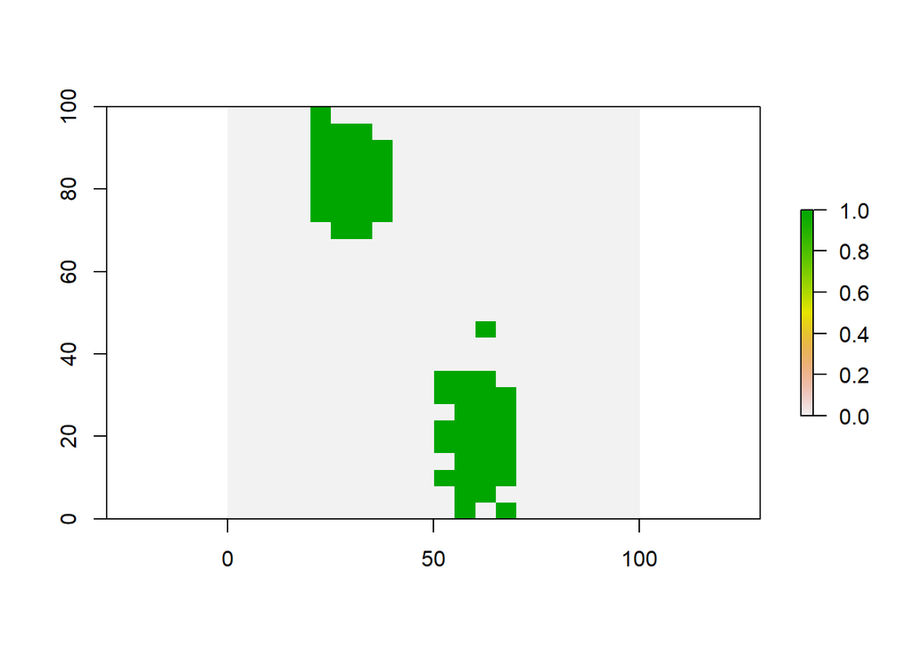

```r
clumped.spdf <- as.data.frame(cbind(e$x,e$y))
clumped.df<- as.data.frame(cbind(e$x,e$y, e$X.1))
#Define the extent for the join count analyses
jc.extent <- extent(0,100,0,100)
#set up a blank raster
r <- raster(nrows=25, ncols=20, ext=jc.extent)

clumped.rast<-rasterize(clumped.spdf, r, field = 1)
clumped.rast[is.na(clumped.rast)] <- 0
# You can plot the result
plot(clumped.rast)
```

```r
# Generate neighbors list
nb.clump <- cell2nb(nrow = nrow(clumped.rast), ncol = ncol(clumped.rast))
# To calculate neighbors for queen configuration
nb.clump.queen <- cell2nb(nrow = nrow(clumped.rast), ncol = ncol(clumped.rast), type = "queen")
# Convert the neighbors list to a 'weights' list;
lwb <- nb2listw(nb.clump, style = "B")
lwb.queen <- nb2listw(nb.clump.queen, style = "B")
#join Counts
joincount.test(as.factor(clumped.rast@data@values), lwb, alternative = "greater")
```

```
##
##  Join count test under nonfree sampling
##
## data:  as.factor(clumped.rast@data@values)
## weights: lwb
##
## Std. deviate for 0 = 15.657, p-value < 2.2e-16
## alternative hypothesis: greater
## sample estimates:
## Same colour statistic           Expectation              Variance
##             815.00000             752.86918              15.74611
##
##
##  Join count test under nonfree sampling
##
## data:  as.factor(clumped.rast@data@values)
## weights: lwb
##
## Std. deviate for 1 = 22.58, p-value < 2.2e-16
## alternative hypothesis: greater
## sample estimates:
## Same colour statistic           Expectation              Variance
##              81.00000              11.78918               9.39491
```

```r
# Second, the permutation-based jon count test; similar to above, and you
# can adjust the number of simulations with the 'nsim' argument
joincount.mc(as.factor(clumped.rast@data@values), lwb, nsim = 999, alternative = "greater")
```

```
##
##  Monte-Carlo simulation of join-count statistic
##
## data:  as.factor(clumped.rast@data@values)
## weights: lwb
## number of simulations + 1: 1000
##
## Join-count statistic for 0 = 815, rank of observed statistic =
## 1000, p-value = 0.001
## alternative hypothesis: greater
## sample estimates:
##     mean of simulation variance of simulation
##              752.72973               16.45594
##
##
##  Monte-Carlo simulation of join-count statistic
##
## data:  as.factor(clumped.rast@data@values)
## weights: lwb
## number of simulations + 1: 1000
##
## Join-count statistic for 1 = 81, rank of observed statistic =
## 1000, p-value = 0.001
## alternative hypothesis: greater
## sample estimates:
##     mean of simulation variance of simulation
##              11.717718               9.785968
```

```r
# Can also compute these for the queen setup; for example, with the
# permutation test:
joincount.mc(as.factor(clumped.rast@data@values), lwb.queen, nsim = 999, alternative = "greater")
```

```
##
##  Monte-Carlo simulation of join-count statistic
##
## data:  as.factor(clumped.rast@data@values)
## weights: lwb.queen
## number of simulations + 1: 1000
##
## Join-count statistic for 0 = 1580, rank of observed statistic =
## 1000, p-value = 0.001
## alternative hypothesis: greater
## sample estimates:
##     mean of simulation variance of simulation
##             1472.02703               74.03434
##
##
##  Monte-Carlo simulation of join-count statistic
##
## data:  as.factor(clumped.rast@data@values)
## weights: lwb.queen
## number of simulations + 1: 1000
##
## Join-count statistic for 1 = 152, rank of observed statistic =
## 1000, p-value = 0.001
## alternative hypothesis: greater
## sample estimates:
##     mean of simulation variance of simulation
##               22.82282               19.13190
```

This is for a dataset with a single, very clumped distribution

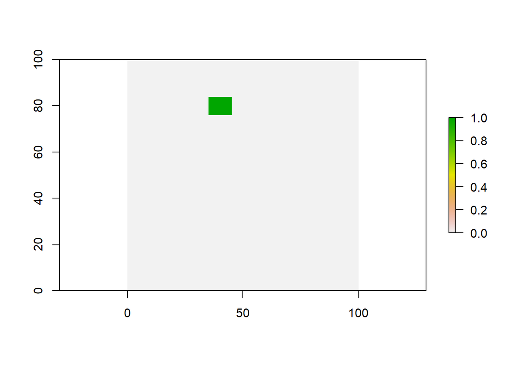

```r
#Rasterize
v_clumped.spdf <- as.data.frame(cbind(n$x,n$y))
v_clump.df<- as.data.frame(cbind(n$x,n$y, n$att))
#Define the extent for the join count analyses
jc.extent <- extent(0,100,0,100)
#set up a blank raster
r <- raster(nrows=25, ncols=20, ext=jc.extent)

v_clumped.rast<-rasterize(v_clumped.spdf, r, field = 1)
v_clumped.rast[is.na(v_clumped.rast)] <- 0
# You can plot the result
plot(v_clumped.rast)
```

```r
# Generate neighbors list
nb.vc <- cell2nb(nrow = nrow(v_clumped.rast), ncol = ncol(v_clumped.rast))
# To calculate neighbors for queen configuration
nb.vc.queen <- cell2nb(nrow = nrow(v_clumped.rast), ncol = ncol(v_clumped.rast), type = "queen")
# Convert the neighbors list to a 'weights' list;
lwb.vc <- nb2listw(nb.vc, style = "B")
lwb.vc.queen <- nb2listw(nb.vc.queen, style = "B")

#join Counts
#joincount.test(as.factor(v_clumped.rast@data@values), lwb, alternative = "greater")
# Second, the permutation-based jon count test; similar to above, and you
# can adjust the number of simulations with the 'nsim' argument
#joincount.mc(as.factor(v_clumped.rast@data@values), lwb, nsim = 999, alternative = "greater")
# Can also compute these for the queen setup; for example, with the
# permutation test:
#joincount.mc(as.factor(v_clumped.rast@data@values), lwb.queen, nsim = 999, alternative = "greater")
```

This is uniformly distributed data

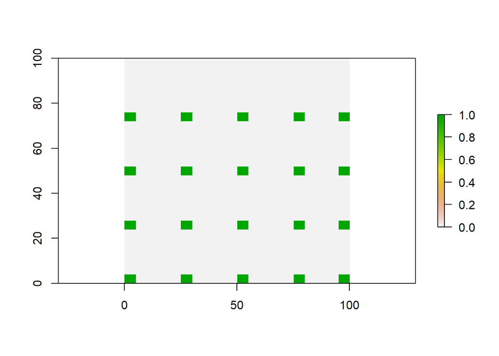

```r
unif.spdf <- as.data.frame(cbind(v$x,v$y))
unif.df<- as.data.frame(cbind(v$x,v$y,v$att))
#Define the extent for the join count analyses
jc.extent <- extent(0,100,0,100)
#set up a blank raster
r <- raster(nrows=25, ncols=20, ext=jc.extent)

unif.rast<-rasterize(unif.spdf, r, field = 1)
unif.rast[is.na(unif.rast)] <- 0

# You can plot the result
plot(unif.rast)
```

```r
# Generate neighbors list
nb.unif <- cell2nb(nrow = nrow(unif.rast), ncol = ncol(unif.rast))
# To calculate neighbors for queen configuration
nb.unif.queen <- cell2nb(nrow = nrow(unif.rast), ncol = ncol(unif.rast), type = "queen")
# Convert the neighbors list to a 'weights' list;
lwb.unif <- nb2listw(nb.unif, style = "B")
lwb.queen <- nb2listw(nb.queen, style = "B")

#join Counts
#joincount.test(as.factor(unif.rast@data@values), lwb, alternative = "greater")
# Second, the permutation-based jon count test; similar to above, and you
# can adjust the number of simulations with the 'nsim' argument
#joincount.mc(as.factor(unif.rast@data@values), lwb, nsim = 999, alternative = "greater")
# Can also compute these for the queen setup; for example, with the
# permutation test:
#joincount.mc(as.factor(unif.rast@data@values), lwb.queen, nsim = 999, alternative = "greater")
```

[figure not shown]

# Continuous Data Statistics

While join count statistics is powerful for prescence/abscence and character attributes, most of the time ecology deals with continuous data and many variables. Statics such as Moran’s I and Geary’s C are often used for to calculate spatial autocorrelation. Using the Harvard Forest example, we can calculate both statistics.

```r
# Use the function 'sample' to get random sample of points; this is done on a SpatialPointsDataFrame , but could also be run on a regular dataframe
acru.sample <- acru.spdf[sample(1:nrow(acru.spdf), 500, replace = FALSE), ]
# plot(acru.sample) #plot if you want to see waht the random sample of data # looks like
acru.sample.df<- as.data.frame(acru.sample)
```

We will use the package spdep. We can use other packages for these statistics. spdep allows for more customization, espeically for distance bands. Distance bands are important as they allow you to define neighborhoods, which determine how far from a point its value will affect other values. In ecology these distance bands can include how far an animal can travel, or perhaps how far a pollutant can travel in a body of water before it’s toxicity disipates.

MONTE CARLO is essentially bootstrapping the NORMAL METHODS.

## Harvard Tree Data

### Moran’s I

```r
moran.out.acru <-moran.test(acru.sample$dbh91, nb2listw(nb.queen, style = "B"))
moran.out.acru
```

```
##
##  Moran I test under randomisation
##
## data:  acru.sample$dbh91
## weights: nb2listw(nb.queen, style = "B")
##
## Moran I statistic standard deviate = -0.58393, p-value = 0.7204
## alternative hypothesis: greater
## sample estimates:
## Moran I statistic       Expectation          Variance
##     -0.0153935903     -0.0020040080      0.0005257834
```

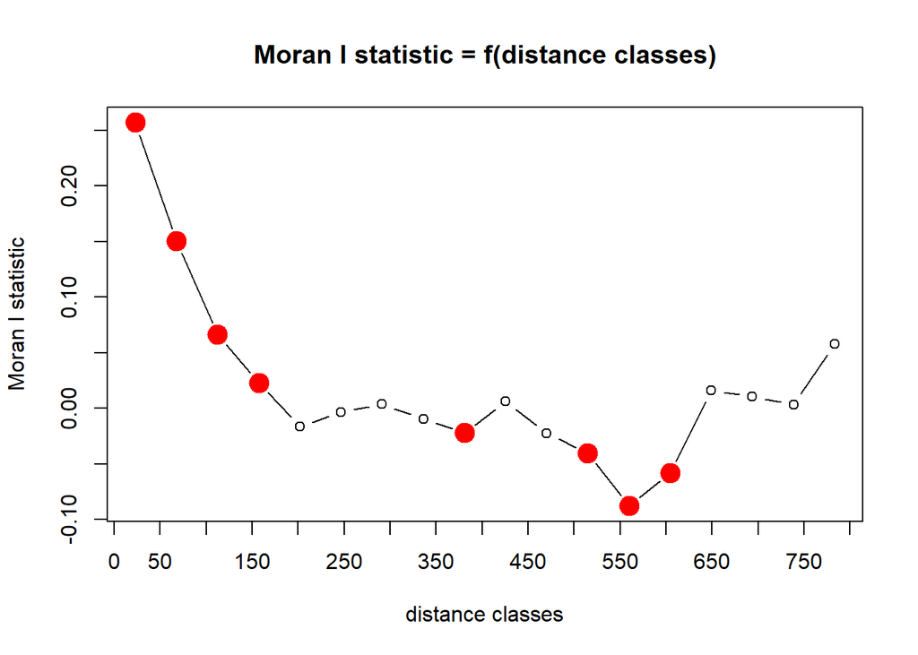

```r
acru.moran <- correlog(coordinates(acru.sample), acru.sample$dbh91, method = "Moran", nbclass = NULL, alternative = "two.sided")
#acru.moran
# Can view the textual results by simply typing 'acru.moran'
plot(acru.moran) #plots the results
```

```r
moran.acru.mc<- moran.mc(acru.sample$dbh91, nb2listw(nb.acru, style = "B"), nsim=99)
moran.acru.mc
```

```
##
##  Monte-Carlo simulation of Moran I
##
## data:  acru.sample$dbh91
## weights: nb2listw(nb.acru, style = "B")
## number of simulations + 1: 100
##
## statistic = 0.009689, observed rank = 66, p-value = 0.34
## alternative hypothesis: greater
```

### Geary C

```r
acru.geary.out<- geary.test(acru.sample$dbh91, nb2listw(nb.acru, style = "B"))
acru.geary.out
```

```
##
##  Geary C test under randomisation
##
## data:  acru.sample$dbh91
## weights: nb2listw(nb.acru, style = "B")
##
## Geary C statistic standard deviate = 0.65865, p-value = 0.2551
## alternative hypothesis: Expectation greater than statistic
## sample estimates:
## Geary C statistic       Expectation          Variance
##       0.978085936       1.000000000       0.001106964
```

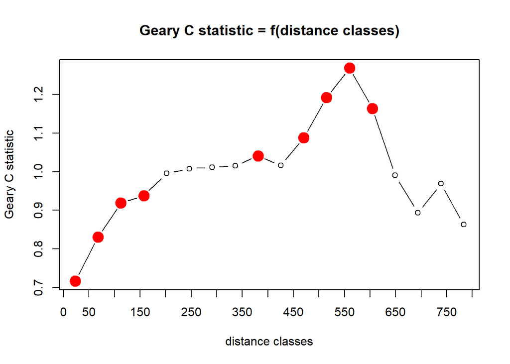

```r
acru.geary <- correlog(coordinates(acru.sample), acru.sample$dbh91, method = "Geary", alternative = "two.sided")
#acru.geary
plot(acru.geary)
```

```r
acru.geary.mc<- geary.mc(acru.sample$dbh91, nb2listw(nb.acru, style = "B"), nsim=99)
acru.geary.mc
```

```
##
##  Monte-Carlo simulation of Geary C
##
## data:  acru.sample$dbh91
## weights: nb2listw(nb.acru, style = "B")
## number of simulations + 1: 100
##
## statistic = 0.97809, observed rank = 26, p-value = 0.26
## alternative hypothesis: greater
```

### Local Moran’s I

```r
acru.rast.count <-rasterize(x=acru.sample, y=acru.rast, field=acru.spdf$dbh91)
acru.rast.count
```

```
## class      : RasterLayer
## dimensions : 25, 20, 500  (nrow, ncol, ncell)
## resolution : 20, 20  (x, y)
## extent     : -300, 100, -700, -200  (xmin, xmax, ymin, ymax)
## crs        : NA
## source     : memory
## names      : layer
## values     : 4.57, 36.07  (min, max)
```

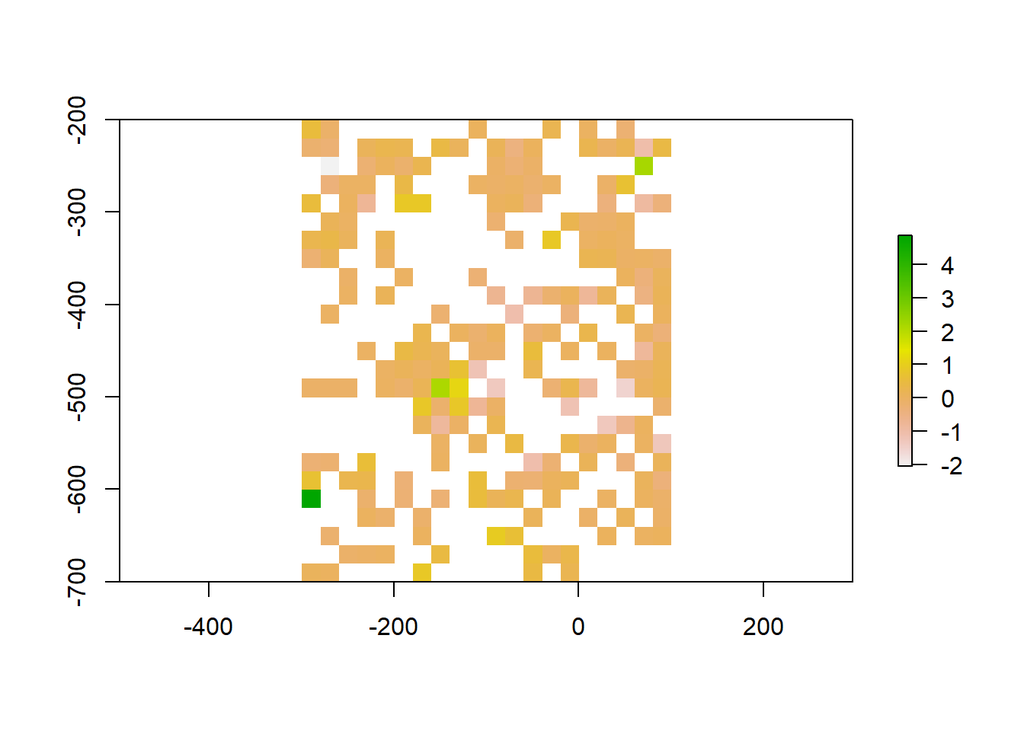

```r
plot(MoranLocal(acru.rast.count))
```

## Simulated Data

Next we will run the same statistical tests as we did with the tree data For our random data

### Random Data

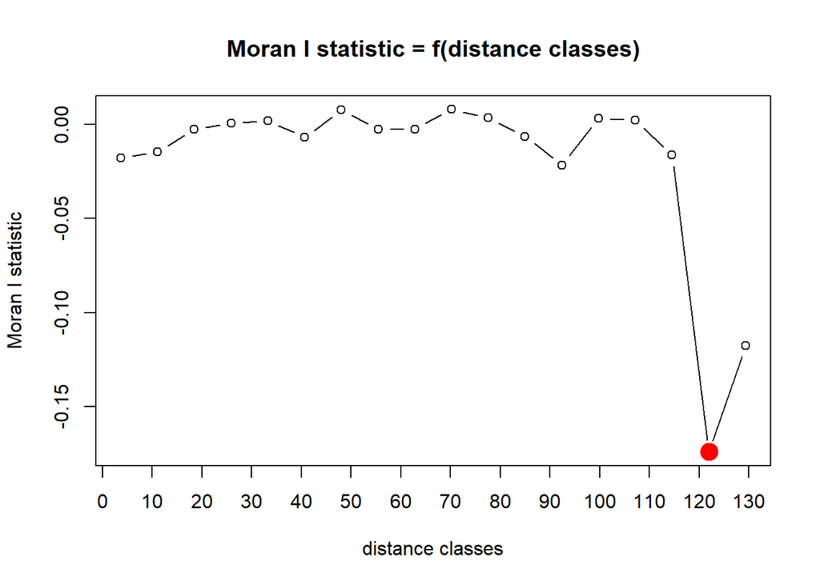

```r
#Moran's I
random.moran <- correlog(coordinates(random.spdf), d$att, method = "Moran", nbclass = NULL, alternative = "two.sided")
# Can view the textual results by simply typing 'random.moran'
plot(random.moran) #plots the results
```

```r
moran.out.rand <- moran.test(random.df$V3, nb2listw(nb.rand, style = "B"))
moran.out.rand
```

```
##
##  Moran I test under randomisation
##
## data:  random.df$V3
## weights: nb2listw(nb.rand, style = "B")
##
## Moran I statistic standard deviate = 14.798, p-value < 2.2e-16
## alternative hypothesis: greater
## sample estimates:
## Moran I statistic       Expectation          Variance
##       0.475910942      -0.002004008       0.001043016
```

```r
moran.rand.mc<- moran.mc(random.df$V3, nb2listw(nb.rand, style = "B"), nsim=99)
moran.rand.mc
```

```
##
##  Monte-Carlo simulation of Moran I
##
## data:  random.df$V3
## weights: nb2listw(nb.rand, style = "B")
## number of simulations + 1: 100
##
## statistic = 0.47591, observed rank = 100, p-value = 0.01
## alternative hypothesis: greater
```

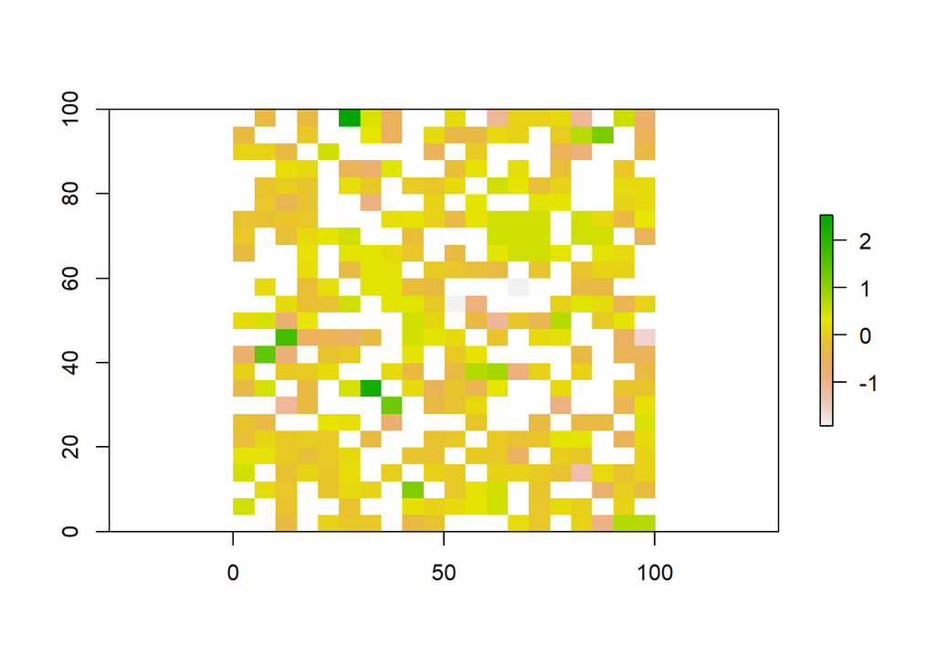

```r
#Local Moran's
random.rast.count <-rasterize(random.spdf, r, fun=function(x,...)length(x))[[1]]
plot(MoranLocal(random.rast.count))
```

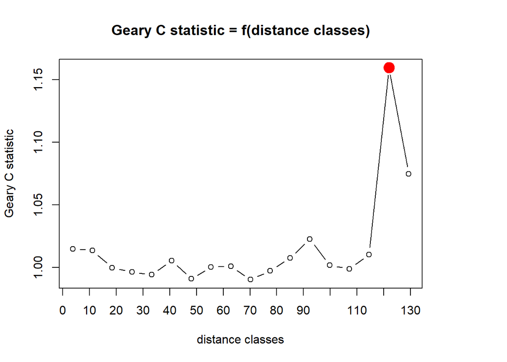

```r
#Geary's C
random.geary <- correlog(coordinates(random.spdf), d$att, method = "Geary", alternative = "two.sided")
plot(random.geary)
```

```r
rand.geary.out<- geary.test(random.df$V3, nb2listw(nb.rand, style = "B"))
rand.geary.out
```

```
##
##  Geary C test under randomisation
##
## data:  random.df$V3
## weights: nb2listw(nb.rand, style = "B")
##
## Geary C statistic standard deviate = 14.644, p-value < 2.2e-16
## alternative hypothesis: Expectation greater than statistic
## sample estimates:
## Geary C statistic       Expectation          Variance
##        0.52779100        1.00000000        0.00103976
```

```r
rand.geary.mc<- geary.mc(random.df$V3, nb2listw(nb.rand, style = "B"), nsim=99)
rand.geary.mc
```

```
##
##  Monte-Carlo simulation of Geary C
##
## data:  random.df$V3
## weights: nb2listw(nb.rand, style = "B")
## number of simulations + 1: 100
##
## statistic = 0.52779, observed rank = 1, p-value = 0.01
## alternative hypothesis: greater
```